# Introduction to Gradient Descent: An Optimization Journey

## 2.4 Visualizing the Descent Path

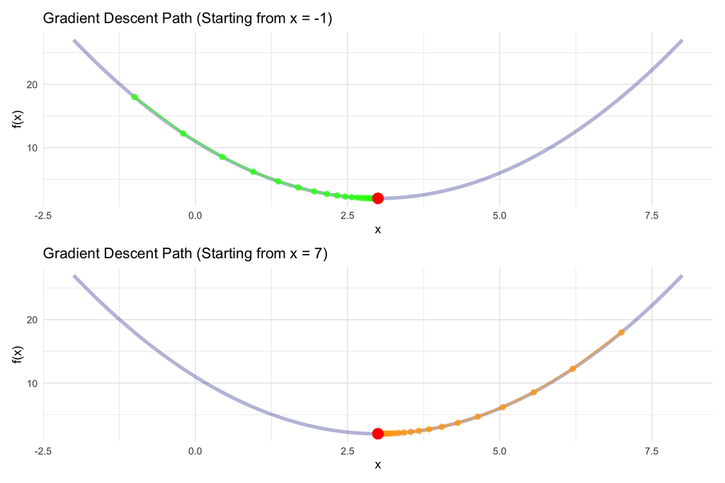

```r
# Create visualization of gradient descent path
p1 <- ggplot(data.frame(x = x_vals, y = y_vals), aes(x = x, y = y)) +
  geom_line(size = 1.5, color = "darkblue", alpha = 0.3) +
  geom_point(data = trajectory1, aes(x = x, y = f_x),
             color = "green", size = 2, alpha = 0.7) +
  geom_path(data = trajectory1, aes(x = x, y = f_x),
            color = "green", size = 1, alpha = 0.5,
            arrow = arrow(length = unit(0.15, "cm"))) +
  geom_point(x = 3, y = f(3), size = 4, color = "red") +
  labs(title = "Gradient Descent Path (Starting from x = -1)",
       x = "x", y = "f(x)") +
  theme_minimal()

p2 <- ggplot(data.frame(x = x_vals, y = y_vals), aes(x = x, y = y)) +
  geom_line(size = 1.5, color = "darkblue", alpha = 0.3) +
  geom_point(data = trajectory2, aes(x = x, y = f_x),
             color = "orange", size = 2, alpha = 0.7) +
  geom_path(data = trajectory2, aes(x = x, y = f_x),
            color = "orange", size = 1, alpha = 0.5,
            arrow = arrow(length = unit(0.15, "cm"))) +
  geom_point(x = 3, y = f(3), size = 4, color = "red") +
  labs(title = "Gradient Descent Path (Starting from x = 7)",
       x = "x", y = "f(x)") +
  theme_minimal()

p1 / p2
```

## 2.5 Key Observations

Notice how:

1. **Both paths converge to the same minimum** (x = 3)
2. **The gradient gets smaller** as we approach the minimum
3. **Steps become smaller** near the minimum (gradient → 0)
4. **Different starting points** lead to the same solution

# 3 Mathematical Foundation

## 3.1 The Gradient Vector

For a function of multiple variables $f(\boldsymbol{\theta})$ where $\boldsymbol{\theta} = [\theta_1, \theta_2, ..., \theta_n]^T$, the gradient is:

$$\nabla f(\boldsymbol{\theta}) = \begin{bmatrix}
\frac{\partial f}{\partial \theta_1} \\
\frac{\partial f}{\partial \theta_2} \\
\vdots \\
\frac{\partial f}{\partial \theta_n}
\end{bmatrix}$$

The gradient points in the direction of **steepest ascent**. To minimize, we move in the **opposite direction**.

## 3.2 The Update Rule

The general gradient descent update rule for multiple parameters is:

$$\boldsymbol{\theta}^{(t+1)} = \boldsymbol{\theta}^{(t)} - \alpha \nabla f(\boldsymbol{\theta}^{(t)})$$

This can be written component-wise as:
$$\theta_i^{(t+1)} = \theta_i^{(t)} - \alpha \frac{\partial f}{\partial \theta_i}\Big|_{\boldsymbol{\theta}^{(t)}}$$

## 3.3 Learning Rate Selection

The learning rate $\alpha$ is crucial:

- **Too small**: Convergence is slow
- **Too large**: May overshoot and diverge
- **Just right**: Efficient convergence

Let’s demonstrate this:

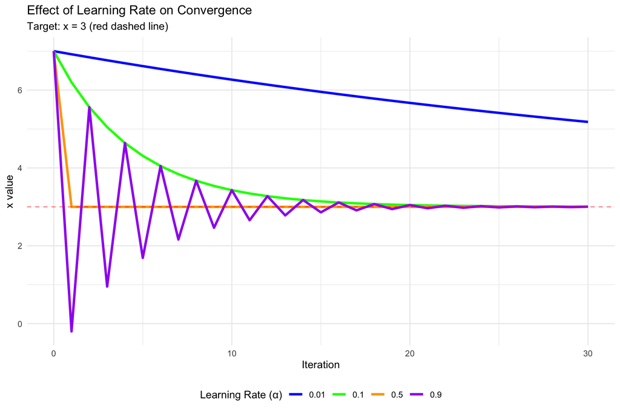

```r
# Compare different learning rates
trajectories <- list()
learning_rates <- c(0.01, 0.1, 0.5, 0.9)

for (lr in learning_rates) {
  traj <- gradient_descent_1d(start_x = 7, learning_rate = lr, n_iterations = 30)
  traj$learning_rate <- lr
  trajectories[[length(trajectories) + 1]] <- traj
}

# Combine all trajectories
all_trajectories <- do.call(rbind, trajectories)
all_trajectories$learning_rate <- factor(all_trajectories$learning_rate)

# Plot convergence for different learning rates
ggplot(all_trajectories, aes(x = iteration, y = x, color = learning_rate)) +
  geom_line(size = 1.2) +
  geom_hline(yintercept = 3, linetype = "dashed", color = "red", alpha = 0.5) +
  scale_color_manual(values = c("blue", "green", "orange", "purple"),
                    name = "Learning Rate (α)") +
  labs(title = "Effect of Learning Rate on Convergence",
       subtitle = "Target: x = 3 (red dashed line)",
       x = "Iteration", y = "x value") +
  theme_minimal() +
  theme(legend.position = "bottom")
```

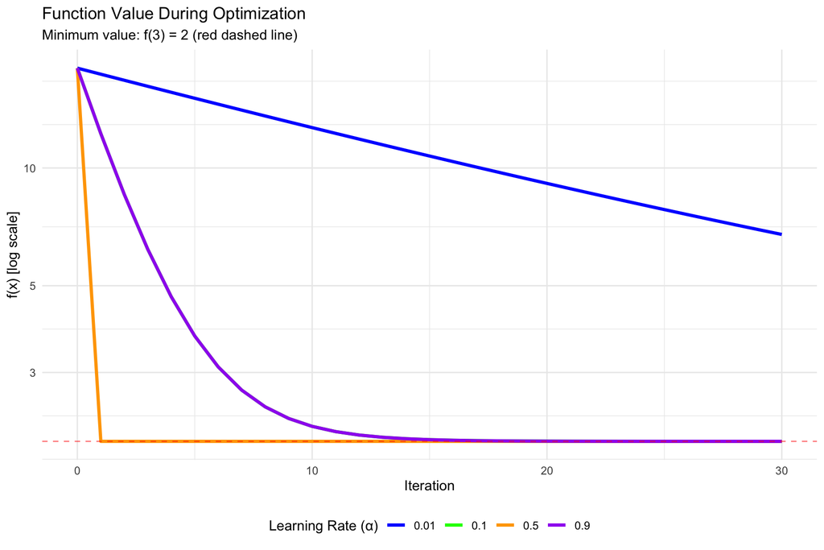

```r
# Show convergence in function value
ggplot(all_trajectories, aes(x = iteration, y = f_x, color = learning_rate)) +
  geom_line(size = 1.2) +
  geom_hline(yintercept = 2, linetype = "dashed", color = "red", alpha = 0.5) +
  scale_color_manual(values = c("blue", "green", "orange", "purple"),
                    name = "Learning Rate (α)") +
  scale_y_log10() +
  labs(title = "Function Value During Optimization",
       subtitle = "Minimum value: f(3) = 2 (red dashed line)",
       x = "Iteration", y = "f(x) [log scale]") +
  theme_minimal() +
  theme(legend.position = "bottom")
```

# 4 Application to Linear Regression

## 4.1 The Optimization Problem

Now let’s apply gradient descent to the problem we solved analytically in Week 1. We want to minimize the Residual Sum of Squares:

$$RSS(\beta_0, \beta_1) = \sum_{i=1}^{n} (y_i - \beta_0 - \beta_1 x_i)^2$$

## 4.2 Deriving the Gradients

To use gradient descent, we need the partial derivatives:

### 4.2.1 For $\beta_0$:

**Step 1: Write out the RSS**
$$\frac{\partial RSS}{\partial \beta_0} = \frac{\partial}{\partial \beta_0} \sum_{i=1}^{n} (y_i - \beta_0 - \beta_1 x_i)^2$$

**Step 2: Apply the sum rule** The derivative of a sum is the sum of derivatives:
$$= \sum_{i=1}^{n} \frac{\partial}{\partial \beta_0} (y_i - \beta_0 - \beta_1 x_i)^2$$

**Step 3: Identify the composition** For each term, we have a composite function: - **Outer function**: $u^2$ where $u = (y_i - \beta_0 - \beta_1 x_i)$ - **Inner function**: $u(\beta_0) = y_i - \beta_0 - \beta_1 x_i$

**Step 4: Apply the chain rule** The chain rule states: $\frac{d}{dx}[f(g(x))] = f'(g(x)) \cdot g'(x)$

For our case: $\frac{d}{d\beta_0}[u^2] = 2u \cdot \frac{du}{d\beta_0}$

**Step 5: Find the outer derivative**
$$\frac{d}{du}[u^2] = 2u = 2(y_i - \beta_0 - \beta_1 x_i)$$

**Step 6: Find the inner derivative**
$$\frac{du}{d\beta_0} = \frac{\partial}{\partial \beta_0}(y_i - \beta_0 - \beta_1 x_i) = 0 - 1 - 0 = -1$$

Note: $y_i$ and $\beta_1 x_i$ are treated as constants with respect to $\beta_0$

**Step 7: Multiply the derivatives (chain rule)**
$$\frac{\partial}{\partial \beta_0}(y_i - \beta_0 - \beta_1 x_i)^2 = 2(y_i - \beta_0 - \beta_1 x_i) \cdot (-1)$$

**Step 8: Simplify and sum**
$$\frac{\partial RSS}{\partial \beta_0} = \sum_{i=1}^{n} -2(y_i - \beta_0 - \beta_1 x_i) = -2 \sum_{i=1}^{n} (y_i - \beta_0 - \beta_1 x_i)$$

### 4.2.2 For $\beta_1$:

**Step 1: Write out the RSS**
$$\frac{\partial RSS}{\partial \beta_1} = \frac{\partial}{\partial \beta_1} \sum_{i=1}^{n} (y_i - \beta_0 - \beta_1 x_i)^2$$

**Step 2: Apply the sum rule**
$$= \sum_{i=1}^{n} \frac{\partial}{\partial \beta_1} (y_i - \beta_0 - \beta_1 x_i)^2$$

**Step 3: Identify the composition** Again, we have a composite function:

- **Outer function**: $u^2$ where $u = (y_i - \beta_0 - \beta_1 x_i)$
- **Inner function**: $u(\beta_1) = y_i - \beta_0 - \beta_1 x_i$

**Step 4: Apply the chain rule**
$$\frac{d}{d\beta_1}[u^2] = 2u \cdot \frac{du}{d\beta_1}$$

**Step 5: Find the outer derivative**
$$\frac{d}{du}[u^2] = 2u = 2(y_i - \beta_0 - \beta_1 x_i)$$

**Step 6: Find the inner derivative**
$$\frac{du}{d\beta_1} = \frac{\partial}{\partial \beta_1}(y_i - \beta_0 - \beta_1 x_i) = 0 - 0 - x_i = -x_i$$

Note: $y_i$ and $\beta_0$ are treated as constants with respect to $\beta_1$, and $\frac{\partial}{\partial \beta_1}(\beta_1 x_i) = x_i$

**Step 7: Multiply the derivatives (chain rule)**
$$\frac{\partial}{\partial \beta_1}(y_i - \beta_0 - \beta_1 x_i)^2 = 2(y_i - \beta_0 - \beta_1 x_i) \cdot (-x_i)$$

**Step 8: Simplify and sum**
$$\frac{\partial RSS}{\partial \beta_1} = \sum_{i=1}^{n} -2x_i(y_i - \beta_0 - \beta_1 x_i) = -2 \sum_{i=1}^{n} x_i(y_i - \beta_0 - \beta_1 x_i)$$

### 4.2.3 Key Insight

The only difference between the two gradients is in **Step 6** - the inner derivative:

- For $\beta_0$: $\frac{\partial}{\partial \beta_0}(y_i - \beta_0 - \beta_1 x_i) = -1$
- For $\beta_1$: $\frac{\partial}{\partial \beta_1}(y_i - \beta_0 - \beta_1 x_i) = -x_i$

This $x_i$ factor in the gradient for $\beta_1$ makes intuitive sense: the slope parameter $\beta_1$ affects the prediction proportionally to the input value $x_i$, so the gradient should also be proportional to $x_i$.

## 4.3 Generating Sample Data

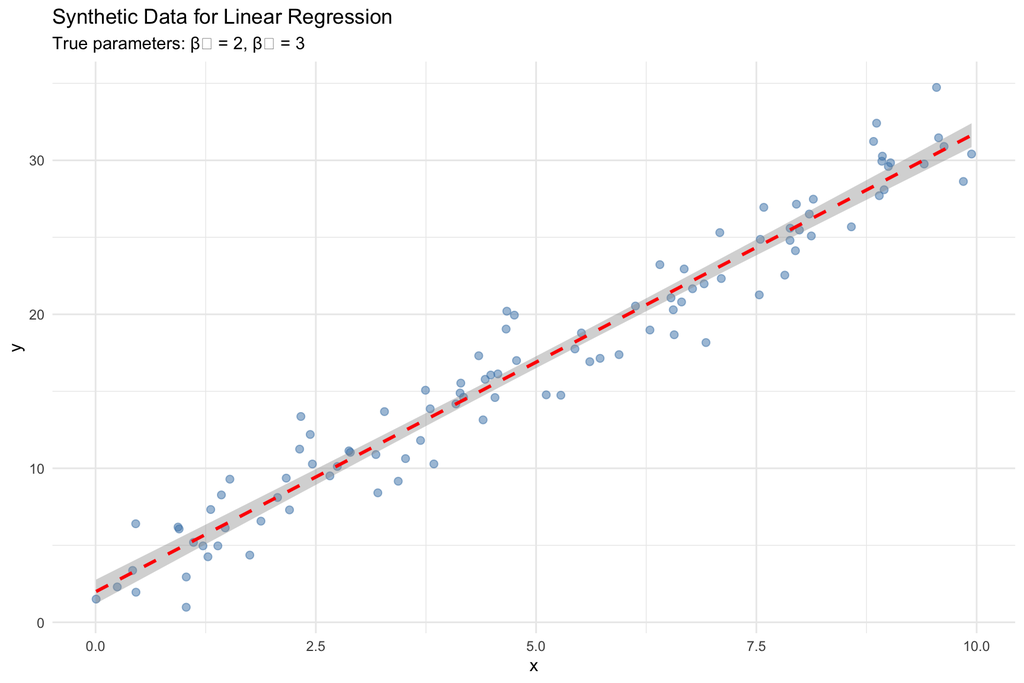

```r
# Set seed for reproducibility
set.seed(123)

# Generate synthetic data
n <- 100
true_beta0 <- 2
true_beta1 <- 3
x <- runif(n, min = 0, max = 10)
epsilon <- rnorm(n, mean = 0, sd = 2)
y <- true_beta0 + true_beta1 * x + epsilon

# Create data frame
data <- data.frame(x = x, y = y)

# Visualize the data
ggplot(data, aes(x = x, y = y)) +
  geom_point(alpha = 0.5, size = 2, color = "steelblue") +
  geom_smooth(method = "lm", se = TRUE, color = "red", linetype = "dashed") +
  labs(title = "Synthetic Data for Linear Regression",
       subtitle = sprintf("True parameters: β₀ = %g, β₁ = %g", true_beta0, true_beta1),
       x = "x", y = "y") +
  theme_minimal()
```

```r
# Calculate analytical solution for comparison
X_matrix <- cbind(1, x)
analytical_solution <- solve(t(X_matrix) %*% X_matrix) %*% t(X_matrix) %*% y
cat("Analytical Solution (from Week 1 method):\n")
```

```
Analytical Solution (from Week 1 method):
```

```r
cat(sprintf("β₀ = %.4f\n", analytical_solution[1]))
```

```
β₀ = 1.9821
```

```r
cat(sprintf("β₁ = %.4f\n", analytical_solution[2]))
```

```
β₁ = 2.9820
```

### 4.3.1 Mathematical Derivation: From Scalar to Matrix Algebra

In Week 1, we derived OLS using scalar algebra with summations. Now let’s see how the **same solution** emerges elegantly using matrix algebra.

#### 4.3.1.1 Setup: The Matrix Formulation

We have $n$ observations with:

- Response vector: $\mathbf{y} = \begin{bmatrix} y_1 \\ y_2 \\ \vdots \\ y_n \end{bmatrix}$ (n × 1)
- Design matrix: $X = \begin{bmatrix} 1 & x_1 \\ 1 & x_2 \\ \vdots & \vdots \\ 1 & x_n \end{bmatrix}$ (n × 2)
- Parameter vector: $\boldsymbol{\beta} = \begin{bmatrix} \beta_0 \\ \beta_1 \end{bmatrix}$ (2 × 1)

The model is: $\mathbf{y} = X\boldsymbol{\beta} + \boldsymbol{\epsilon}$

The **scalar form** we saw in Week 1:
$$RSS(\beta_0, \beta_1) = \sum_{i=1}^{n} (y_i - \beta_0 - \beta_1 x_i)^2$$

can be written in **matrix form** as:
$$RSS(\boldsymbol{\beta}) = (\mathbf{y} - X\boldsymbol{\beta})^T(\mathbf{y} - X\boldsymbol{\beta})$$

This is the squared length of the residual vector $\mathbf{e} = \mathbf{y} - X\boldsymbol{\beta}$.

Expanding the matrix product:
$$RSS(\boldsymbol{\beta}) = \mathbf{y}^T\mathbf{y} - \mathbf{y}^TX\boldsymbol{\beta} - \boldsymbol{\beta}^TX^T\mathbf{y} + \boldsymbol{\beta}^TX^TX\boldsymbol{\beta}$$

Since $\mathbf{y}^TX\boldsymbol{\beta}$ is a scalar, it equals its transpose:
$$\mathbf{y}^TX\boldsymbol{\beta} = (\mathbf{y}^TX\boldsymbol{\beta})^T = \boldsymbol{\beta}^TX^T\mathbf{y}$$

Therefore:
$$RSS(\boldsymbol{\beta}) = \mathbf{y}^T\mathbf{y} - 2\boldsymbol{\beta}^TX^T\mathbf{y} + \boldsymbol{\beta}^TX^TX\boldsymbol{\beta}$$

To minimize RSS, we take the derivative with respect to $\boldsymbol{\beta}$ and set it to zero.

**Matrix Calculus Rules** we need:

1. $\frac{\partial}{\partial \boldsymbol{\beta}}(\mathbf{a}^T\boldsymbol{\beta}) = \mathbf{a}$ (derivative of linear term)
2. $\frac{\partial}{\partial \boldsymbol{\beta}}(\boldsymbol{\beta}^TA\boldsymbol{\beta}) = 2A\boldsymbol{\beta}$ (derivative of quadratic form, where A is symmetric)

Applying these rules:
$$\frac{\partial RSS}{\partial \boldsymbol{\beta}} = \frac{\partial}{\partial \boldsymbol{\beta}}\left[\mathbf{y}^T\mathbf{y} - 2\boldsymbol{\beta}^TX^T\mathbf{y} + \boldsymbol{\beta}^TX^TX\boldsymbol{\beta}\right]$$

$$= 0 - 2X^T\mathbf{y} + 2X^TX\boldsymbol{\beta}$$

$$= -2X^T\mathbf{y} + 2X^TX\boldsymbol{\beta}$$

For the minimum, we set $\frac{\partial RSS}{\partial \boldsymbol{\beta}} = \mathbf{0}$:

$$-2X^T\mathbf{y} + 2X^TX\boldsymbol{\beta} = \mathbf{0}$$

Divide by 2:
$$X^TX\boldsymbol{\beta} = X^T\mathbf{y}$$

These are the **Normal Equations** in matrix form!

If $X^TX$ is invertible (which requires the columns of $X$ to be linearly independent), we can multiply both sides by $(X^TX)^{-1}$:

$$(X^TX)^{-1}X^TX\boldsymbol{\beta} = (X^TX)^{-1}X^T\mathbf{y}$$

Since $(X^TX)^{-1}X^TX = I$ (the identity matrix):
$$\boldsymbol{\beta} = (X^TX)^{-1}X^T\mathbf{y}$$

This is the **OLS solution in matrix form**!

#### 4.3.1.2 Connection to Week 1’s Scalar Algebra

The matrix formula $\boldsymbol{\beta} = (X^TX)^{-1}X^T\mathbf{y}$ is equivalent to the scalar formulas we derived in Week 1:

For our simple linear regression with $X = \begin{bmatrix} 1 & x_1 \\ \vdots & \vdots \\ 1 & x_n \end{bmatrix}$:

$$X^TX = \begin{bmatrix} n & \sum x_i \\ \sum x_i & \sum x_i^2 \end{bmatrix}$$

$$X^T\mathbf{y} = \begin{bmatrix} \sum y_i \\ \sum x_i y_i \end{bmatrix}$$

Computing $(X^TX)^{-1}X^T\mathbf{y}$ with these matrices yields exactly the formulas:

$$\beta_1 = \frac{\sum(x_i - \bar{x})(y_i - \bar{y})}{\sum(x_i - \bar{x})^2}$$

$$\beta_0 = \bar{y} - \beta_1\bar{x}$$

that we derived using summation notation in Week 1!

**Why Matrix Form is Powerful**

The matrix formulation $\boldsymbol{\beta} = (X^TX)^{-1}X^T\mathbf{y}$:

1. **Generalizes immediately** to multiple predictors (just add more columns to X)
2. **Connects to geometric intuition** (projection onto column space of X)
3. **Enables computational implementation** (one matrix equation instead of many formulas)
4. **Reveals the structure** of the problem (symmetric matrix $X^TX$, projection matrix $X(X^TX)^{-1}X^T$)
5. **Leads naturally to gradient descent** (when we can’t or don’t want to invert $X^TX$)

## 4.4 Implementing Gradient Descent for Regression

```r
# Initialize parameters
beta0 <- 0
beta1 <- 0
learning_rate <- 0.01
n_iterations <- 1000
n <- length(x)

# Gradient descent loop
for (i in 1:n_iterations) {
  # Compute predictions and residuals
  predictions <- beta0 + beta1 * x
  residuals <- y - predictions

  # Compute gradients
  grad_beta0 <- -2 * sum(residuals) / n
  grad_beta1 <- -2 * sum(x * residuals) / n

  # Update parameters
  beta0 <- beta0 - learning_rate * grad_beta0
  beta1 <- beta1 - learning_rate * grad_beta1
}

# Show final results
cat("\nGradient Descent Results:\n")
```

```
Gradient Descent Results:
```

```r
cat(sprintf("Final: β₀ = %.4f, β₁ = %.4f\n", beta0, beta1))
```

```
Final: β₀ = 1.9697, β₁ = 2.9839
```

```r
# Compare with analytical solution
cat("\nComparison with Analytical Solution:\n")
```

```
Comparison with Analytical Solution:
```

```r
comparison <- data.frame(
  Method = c("Analytical (Week 1)", "Gradient Descent"),
  Beta0 = c(analytical_solution[1], beta0),
  Beta1 = c(analytical_solution[2], beta1)
)

kable(comparison, digits = 4,
      caption = "Comparison: Gradient Descent vs Analytical Solution") %>%
  kable_styling(bootstrap_options = c("striped", "hover"))
```

Comparison: Gradient Descent vs Analytical Solution

| Method | Beta0 | Beta1 |
| --- | --- | --- |
| Analytical (Week 1) | 1.9821 | 2.9820 |
| Gradient Descent | 1.9697 | 2.9839 |

# 5 Connection to BLUE Properties

## 5.1 Why Gradient Descent Finds the BLUE Estimator

Recall from Week 2 that the sample mean (and by extension, OLS estimators) are BLUE:

- **Best**: Minimum variance among linear unbiased estimators
- **Linear**: Linear combination of observations
- **Unbiased**: Expected value equals true parameter

When we use gradient descent to minimize RSS, we’re finding the same solution as the analytical OLS formula because:

1. **The RSS is convex** in the parameters (unique global minimum)
2. **The gradient at the minimum is zero** (same first-order conditions as OLS)
3. **The solution satisfies** the normal equations from Week 1

```r
# Verify that gradient descent solution satisfies normal equations
beta_gd <- c(beta0, beta1)
beta_ols <- as.vector(analytical_solution)

# Normal equations: X'X β = X'y
X_matrix <- cbind(1, x)
normal_lhs_gd <- t(X_matrix) %*% X_matrix %*% beta_gd
normal_rhs <- t(X_matrix) %*% y
normal_lhs_ols <- t(X_matrix) %*% X_matrix %*% beta_ols

# Compare
normal_comparison <- data.frame(
  Equation = c("X'Xβ (GD)", "X'Xβ (OLS)", "X'y"),
  `First_Component` = c(normal_lhs_gd[1], normal_lhs_ols[1], normal_rhs[1]),
  `Second_Component` = c(normal_lhs_gd[2], normal_lhs_ols[2], normal_rhs[2])
)

kable(normal_comparison, digits = 4,
      caption = "Verification: Both Methods Satisfy the Normal Equations") %>%
  kable_styling(bootstrap_options = c("striped", "hover"))
```

Verification: Both Methods Satisfy the Normal Equations

| Equation | First_Component | Second_Component |
| --- | --- | --- |
| X'Xβ (GD) | 1684.631 | 10798.26 |
| X'Xβ (OLS) | 1684.928 | 10798.21 |
| X'y | 1684.928 | 10798.21 |

```r
cat("\n✓ Both gradient descent and OLS satisfy X'Xβ = X'y\n")
```

```
✓ Both gradient descent and OLS satisfy X'Xβ = X'y
```

```r
cat("✓ Therefore, gradient descent finds the BLUE estimator!\n")
```

```
✓ Therefore, gradient descent finds the BLUE estimator!
```

# 6 Practical Considerations

## 6.1 Advantages of Gradient Descent

1. **Scalability**: Works with millions of parameters
2. **Memory Efficiency**: No need to store or invert large matrices
3. **Flexibility**: Can optimize any differentiable objective function
4. **Online Learning**: Can update with new data incrementally

## 6.2 Disadvantages

1. **Requires tuning**: Learning rate selection is crucial
2. **Iterative**: May need many iterations to converge
3. **Local minima**: For non-convex problems (not an issue for OLS)
4. **Numerical precision**: Can have stability issues with poor scaling

## 6.3 Feature Scaling

Gradient descent converges faster when features are on similar scales:

```r
# Demonstrate effect of feature scaling
set.seed(456)

# Create data with different scales
n <- 100
x1 <- runif(n, min = 0, max = 1)        # Small scale
x2 <- runif(n, min = 1000, max = 5000)  # Large scale
y <- 2 + 3*x1 + 0.001*x2 + rnorm(n, sd = 0.5)

# Standardize features
x1_scaled <- (x1 - mean(x1)) / sd(x1)
x2_scaled <- (x2 - mean(x2)) / sd(x2)

# Run gradient descent on both versions
X_unscaled <- cbind(1, x1, x2)
X_scaled <- cbind(1, x1_scaled, x2_scaled)

# Simple gradient descent function
run_gd <- function(X, y, n_iter = 1000, lr = 0.0001) {
  beta <- c(0, 0, 0)
  for (i in 1:n_iter) {
    predictions <- X %*% beta
    grad <- -2 * t(X) %*% (y - predictions) / n
    beta <- beta - lr * grad
  }
  return(beta)
}

# Compare results
beta_unscaled <- run_gd(X_unscaled, y)
beta_scaled <- run_gd(X_scaled, y)

# Create comparison table
comparison <- data.frame(
  Method = c("Without Scaling", "With Scaling"),
  Beta0 = c(beta_unscaled[1], beta_scaled[1]),
  Beta1 = c(beta_unscaled[2], beta_scaled[2]),
  Beta2 = c(beta_unscaled[3], beta_scaled[3])
)

kable(comparison, digits = 4,
      caption = "Feature Scaling Effect (Learning Rate = 0.0001, 1000 iterations)") %>%
  kable_styling(bootstrap_options = c("striped", "hover"))
```

Feature Scaling Effect (Learning Rate = 0.0001, 1000 iterations)

| Method | Beta0 | Beta1 | Beta2 |
| --- | --- | --- | --- |
| Without Scaling | NaN | NaN | NaN |
| With Scaling | 1.2231 | 0.1729 | 0.2236 |

## 6.4 When to Use Gradient Descent vs Analytical Solutions

When to Use Gradient Descent vs Analytical Solutions

| Scenario | Analytical Solution | Gradient Descent |
| --- | --- | --- |
| Small dataset (n < 10,000) | ✓ Preferred | Works but slower |
| Large dataset (n > 1,000,000) | ✗ Too slow/memory | ✓ Preferred |
| Few features (p < 100) | ✓ Preferred | Works but slower |
| Many features (p > 10,000) | ✗ Matrix too large | ✓ Preferred |
| Linear model | ✓ Available | ✓ Finds same solution |
| Non-linear model | ✗ No closed form | ✓ Only option |
| Real-time/online learning | ✗ Not suitable | ✓ Preferred |
| Batch processing | ✓ Preferred | Works |
| Need exact solution | ✓ Preferred | If high precision |
| Approximate solution OK | ✓ If tolerance high | ✓ Preferred |

# 7 Real-World Extensions

While we’ve focused on simple gradient descent, modern applications use several important variants:

## 7.1 Stochastic Gradient Descent (SGD)

Instead of using all data points to compute the gradient:

- Use one random sample at a time
- Much faster per iteration
- Adds noise that can help escape local minima
- Essential for large datasets

## 7.2 Mini-Batch Gradient Descent

A compromise between full batch and SGD:

- Use a small subset (e.g., 32-256 samples) per iteration
- Balances computational efficiency with stability
- Standard in deep learning

## 7.3 Adaptive Learning Rates

Modern optimizers adjust the learning rate automatically:

- **AdaGrad**: Adapts learning rate per parameter
- **RMSprop**: Uses moving average of squared gradients
- **Adam**: Combines momentum with adaptive learning rates

## 7.4 Momentum

Add a “velocity” term to smooth the optimization path:
$$\boldsymbol{v}_{t+1} = \gamma \boldsymbol{v}_t + \alpha \nabla f(\boldsymbol{\theta}_t)$$
$$\boldsymbol{\theta}_{t+1} = \boldsymbol{\theta}_t - \boldsymbol{v}_{t+1}$$

This helps:

- Accelerate convergence in consistent directions
- Dampen oscillations
- Navigate ravines in the loss landscape

# 8 Summary and Key Takeaways

## 8.1 The Bigger Picture

Gradient descent is the foundation for modern machine learning:

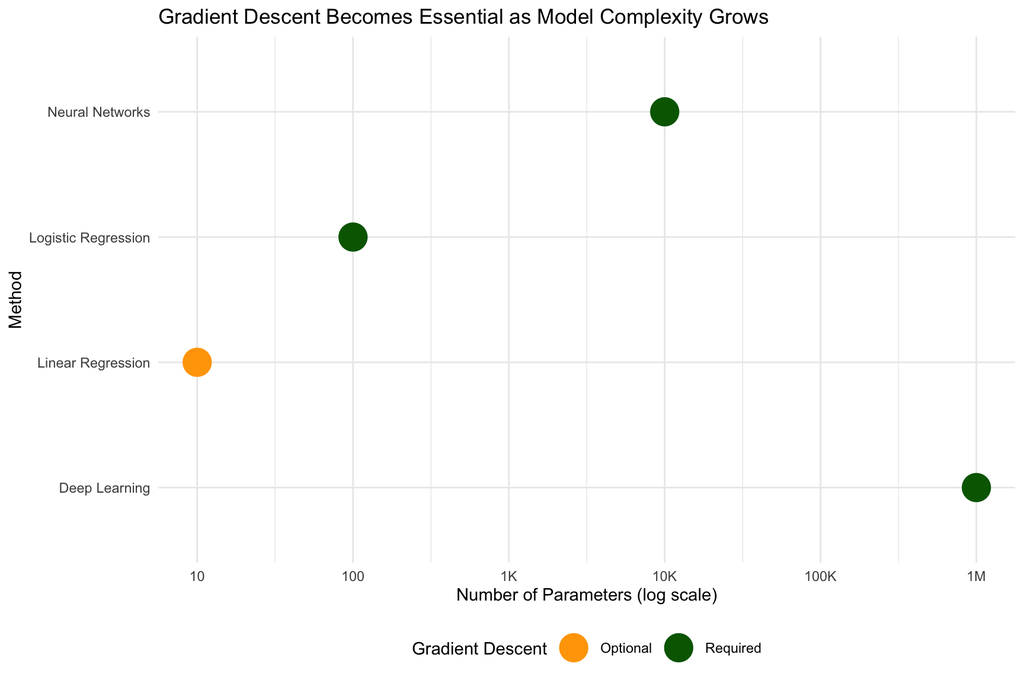

```r
# Create a summary visualization
methods <- data.frame(
  Method = c("Linear Regression", "Logistic Regression",
             "Neural Networks", "Deep Learning"),
  Parameters = c(10, 100, 10000, 1000000),
  Analytical = c("Yes", "No", "No", "No"),
  GD_Essential = c("Optional", "Required", "Required", "Required")
)

ggplot(methods, aes(x = log10(Parameters), y = Method)) +
  geom_point(aes(color = GD_Essential), size = 8) +
  scale_color_manual(values = c("Optional" = "orange",
                               "Required" = "darkgreen")) +
  scale_x_continuous(breaks = 1:6,
                    labels = c("10", "100", "1K", "10K", "100K", "1M")) +
  labs(title = "Gradient Descent Becomes Essential as Model Complexity Grows",
       x = "Number of Parameters (log scale)",
       y = "Method",
       color = "Gradient Descent") +
  theme_minimal() +
  theme(legend.position = "bottom")
```

## 8.2 Final Thoughts

> “Gradient descent is not just an algorithm—it’s a fundamental principle that connects simple linear regression to the most advanced deep learning models.”

Understanding gradient descent provides:

- **Intuition** for how machine learning algorithms learn.
- **Foundation** for understanding modern optimizers
- **Bridge** between classical statistics and machine learning
- **Practical tool** for large-scale optimization

In upcoming weeks, we can extend these concepts to:

- Regularization (L1/L2 penalties)
- Logistic regression
- Multi-class classification
- Neural network backpropagation

The journey from the analytical solutions of Week 1, through the statistical properties of Week 2, to the iterative optimization of Week 3, shows how different perspectives on the same problem enrich our understanding and expand our toolkit.

### 8.2.1 References

- Boyd, S., & Vandenberghe, L. (2004). *Convex Optimization*. Cambridge University Press.
- Goodfellow, I., Bengio, Y., & Courville, A. (2016). *Deep Learning*. MIT Press.
- Ruder, S. (2016). An overview of gradient descent optimization algorithms. *arXiv preprint arXiv:1609.04747*.
- Sutton, R. S., & Barto, A. G. (2018). *Reinforcement Learning: An Introduction*. MIT Press.